# Homework 1

Davide Cacciatore, Francesca Possenti, Letizia Russo

4/12/2021

# Exercise 2

#### *2.1. For a fixed h, what kind of constrains we need to impose over the parameter vector $(\pi_1,...,\pi_N)$ for $\hat{f}(x; \theta)$ to be a legit density?*

A function $f(x)$ is a legit density function if it satisfies the following two properties:

- **Non-negativity**: $f(x) \ge 0$ for any $x \in R$;
- **Its integral over $R$ equals $1$**: $\int_{-\infty}^{\infty} f(x)dx = 1$

We defined a stepwise function (an histogram) with density $\hat{f}(x;\theta)$, which approximates the true Beta model density since $F_Y$ is an approximation of $F_{X}$:

$$\hat{f}(x;\theta) = \sum_{j=1}^{N}\frac{\pi_j}{h} \mathbb{1}(x \in B_{j})$$

where $\theta = (h, \pi_1, . . . , \pi_N )$ and $\mathbb{1}(x \in B_{j})dx$ is the indicator function of the $j^{th}$ bin.

In order to obtain a legit density function, we must impose that the integral of the function is equal to one:

$$\int_{R}\hat{f}(x;\theta)dx=1 \Leftrightarrow \sum_{j=1}^{N}\frac{\pi_j}{h}\int_{R} \mathbb{1} (x \in B_{j})dx =1$$

Since we know that $\int_{B}dx=h$, we obtain:
$$\sum_{j=1}^{N}\frac{\pi_j}{h}h=\sum_{j=1}^{N}\pi_j=1$$
This allows us to say that $\pi_j$ is a probability and $\frac{\pi_j}{h}$ is a density. In fact, since we’re working on an histogram, we know that each bar’s height represents a frequency, so we get the density dividing them by the correspondent $h$, that is the size of each bin.

#### *2.2 Implement $\hat{f}(x;\theta)$ and its corresponding quantile function, say $F^{-1}(x;\theta)$, in R.*

We randomly generate 10000 observations assuming that $Y \sim Beta(\alpha,\beta)$

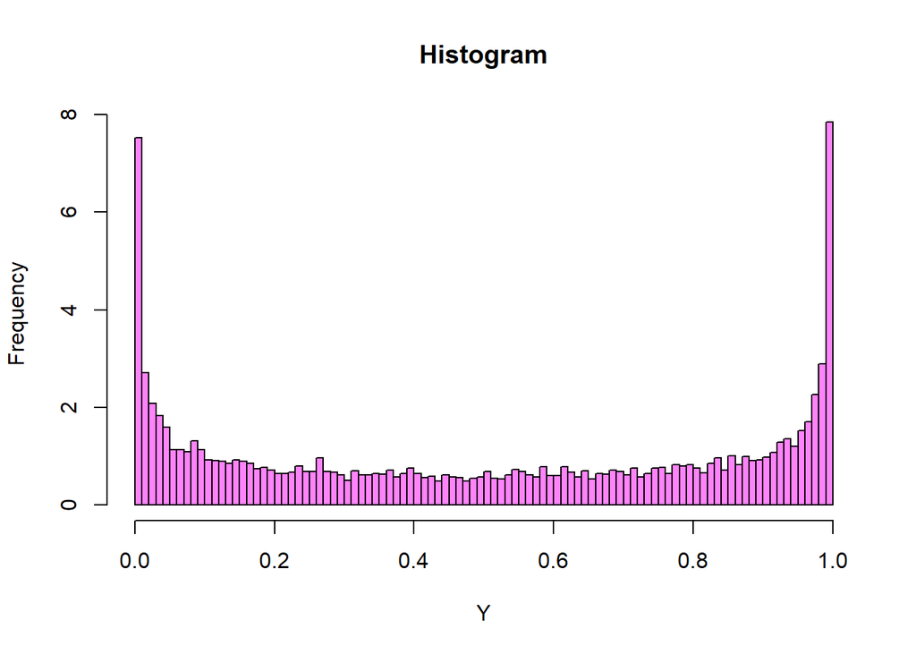

```r
# Set alpha and beta 0.45
Y = rbeta(10000, 0.45, 0.45)
h = 0.01 # length of the bins
N = round(1/h) # number of bins

# Plot the histogram
hist(Y, breaks = N, main = "Histogram", col="orchid1",
     ylab = "Frequency", xlab = "Y", freq = F)
```

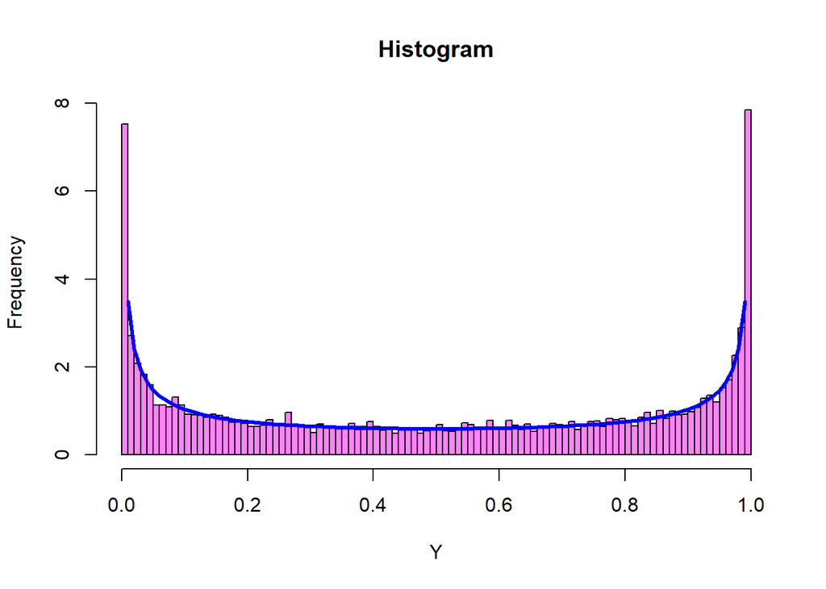

```r
# Add to the plot the density of the true Beta.
X <- function(x) dbeta(x, 0.45, 0.45)
histogram = hist(Y, breaks=N, main="Histogram", freq = F,
                 col="orchid1", ylab = "Frequency", xlab = "Y")
curve(X, 0, 1, add = T, col='blue', lwd = 3)
```

We know that the sum of the area of all the bins need to be equal to one.
$$\sum_{j=1}^{N}\pi_j = 1$$

```r
# histogram$density is the vector with all the heigts of the rectangles
# h is the length of each bins
pi <- histogram$density*h
sum(pi)
```

```
## [1] 1
```

Now we can compute the $\hat{f}(x;\theta)$ function.

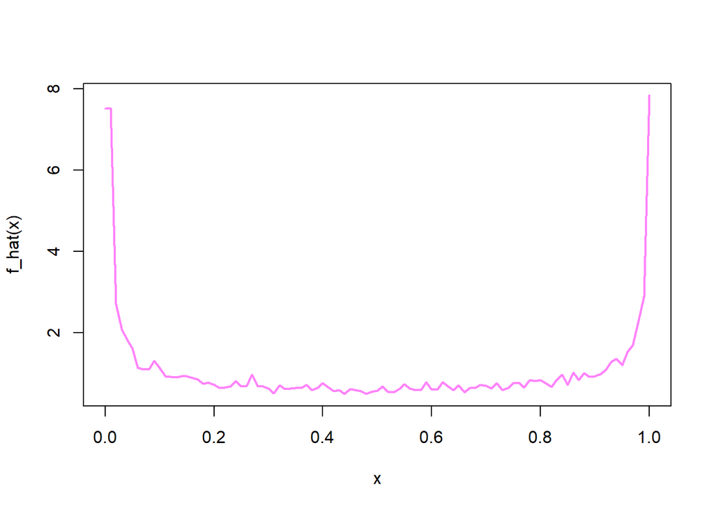

```r
bins <- histogram$breaks # Set the bins
d <- histogram$density # Set the height of the bins

# Compute the function
f_hat <- function(x) {
  f_r <- 0
  for (j in 1:N){
    f_r = f_r + d[j]*(x >= bins[j])*(x < bins[j+1])
  }
  return (f_r)
}

# Let's see the plot of this function
curve(f_hat(x), from=0, to=1, lwd=2, col='orchid1')
```

```r
# Let's see if this is a proper density
# We must expect an area under the curve, from 0 to 1, equal to 1
# In order to evaluate this integral, we had to set an higher number of subdivisions
integrate(f_hat, lower=0, upper=1, subdivisions=1000)
```

```
## 1.000007 with absolute error < 0.00012
```

We can say that this is a proper density, now we want to evaluate its quantile function $\hat{F}^{-1}(x;\theta)$.

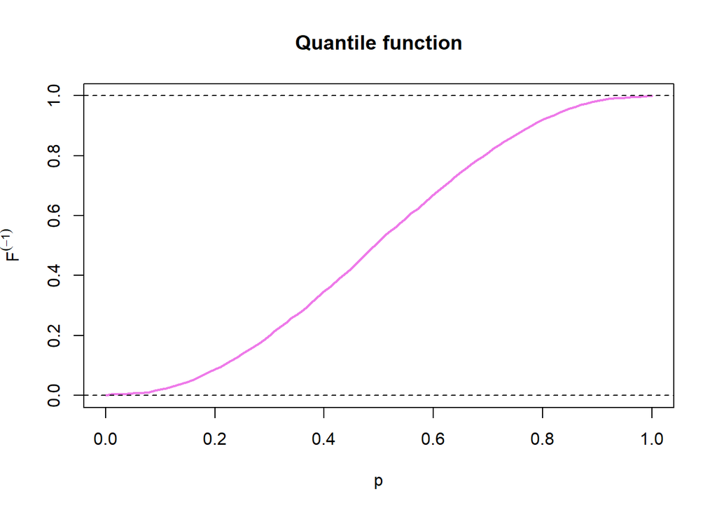

```r
# We can get the quantile function via the density itself

# Consider the value of the integral, keeping in mind that when t>=1
# That value should be 1
my_int <- function(t) ifelse(t >= 1, 1,
                             integrate(f_hat, -Inf, t,
                                       subdivisions = 1000)$value)
my_eq <- function(y, p) my_int(y) - p
F_q <- function(p) uniroot(my_eq, c(0,1), p = p)$root

# Now that we have our quantile function we can plot it
# But first we need to vectorize it
F_q_vec <- Vectorize(F_q, "p")
curve(F_q_vec(x), from = 0, to = 1,
      xlab = "p", ylab = expression(F^(-1)),
      lwd = 2, col = "orchid2", main='Quantile function')
abline(h=0, lty=2)
abline(h=1, lty=2)
```

#### *2.3 Pick a specific $(\alpha, \beta)$ pair and, for any $h > 0$, fix $\pi_j = \int_{B_j}f(x)dx$.*

#### *Notice that now $\hat{f}(\cdot ; \theta)$ depends on a single tuning parameter, the binwidth $h$.*

#### *For this reason, let’s simplify the notation and use $\hat{f_h}(\cdot)$ and $\hat{F_{h}}^{-1}(\cdot)$ to denote the approximant density and its quantile function respectively.*

#### *Let $\epsilon > 0$ be an approximation level you are targeting in terms of $p = 1$ Wasserstein distance, meaning that you’re looking for the largest binwidth $h$ (i.e. the coarsest approximation) such that:*

$$W_{L_1,1}(f,\hat{f_h})=\Bigg(\int_{0}^{1}|F^{-1}(z)-\hat{F_h}^{-1}(z)|dz\Bigg) \le \epsilon$$

#### *Use any (reasonable) technique you like, to study how $h$ varies with $\epsilon$ (… and properly comment the results).*

First of all, we implemented from scratch a p=1 **Wasserstein distance** that, for given $h$ and $\epsilon$, evaluates the integral over the absolute difference of the two quantile functions and, if the output value is less or equal than the approximation level, it returns the given $h$.

```r
# Generate the quantile function F^-1 of Y~Beta(0.45, 0.45)
Q_beta <- function(p) qbeta(p, 0.45, 0.45)

# Define a function that evaluate the p=1 Wasserstein distance
my_wasserstein <- function(h, e) {

  # Input:
  #       h <- binwidth
  #       e <- approximation level

  N = round(1/h)
  bins <- seq(0, 1, h) # Set the bins
  d <- hist(Y, breaks=N)$density # Set the height of the bins

  # Compute the function to evaluate f_hat
  f_hat <- function(x) {
    f_r <- 0
    for (j in 1:N){
      f_r = f_r + d[j]*(x >= bins[j])*(x < bins[j+1])
    }
    return (f_r)
  }

  # Get its quantile function
  my_int <- function(t) ifelse(t >= 1, 1,
                               integrate(f_hat, -Inf, t,
                                         subdivisions = 100/h)$value)
  my_eq <- function(y, p) my_int(y) - p
  F_q <- function(p) uniroot(my_eq, c(0,1), p = p)$root
  F_q_vec <- Vectorize(F_q, "p")

  # Evaluate as a function the absolute distance between the
  # empirical quantile of beta and the approximated one
  dist <- function(x) abs(Q_beta(x) - F_q_vec(x))

  # Evaluate the integral from 0 to 1 of the dist function <- Wasserstein distance
  wass <- integrate(dist, lower=0, upper=1, subdivisions=100/h)$value

  # If the value of the integral is less or equal than the approximation level
  # return the used binwidth,
  # else return 0
  if (wass <= e) {
    return(h)
  }else{
    return(0)
  }
}
```

We want to test this function for different approximations levels $\epsilon$ and with different binwidths $h$, in order to find, for each $\epsilon$, the largest $h$ between the given ones that verifies the inequality.

```r
# Set 6 possible binwidths
binwidths <- c(0.5, 0.25, 0.2, 0.1, 0.05, 0.01)

# Set 4 approximations level we want to test
eps <- c(0.005, 0.01, 0.05, 0.1)

# Initialize a NA matrix where to store our results
results = matrix(data = NA, nrow = 4, ncol = 6)

# Check for each epsilon
for (e in 1:length(eps)) {
  # Check for each binwidth
  for (h in 1:length(binwidths)) {
    # Run the Wasserstein distance
    results[e,h] <- my_wasserstein(binwidths[h], eps[e])
  }
}
```

```r
# Initialize the vector with all the largest h that satisfy the inequality
largest_h <- replicate(0, 4)

# For each epsilon check what is the maximum h between the ones we choose to analyze
for (i in 1:length(eps)) {
  largest_h[i] <- max(results[i,])
}

# Organize the results in a dataframe
table <- data.frame(eps = eps, largest_h = unlist(largest_h))
table
```

```
##     eps largest_h
## 1 0.005      0.00
## 2 0.010      0.05
## 3 0.050      0.25
## 4 0.100      0.50
```

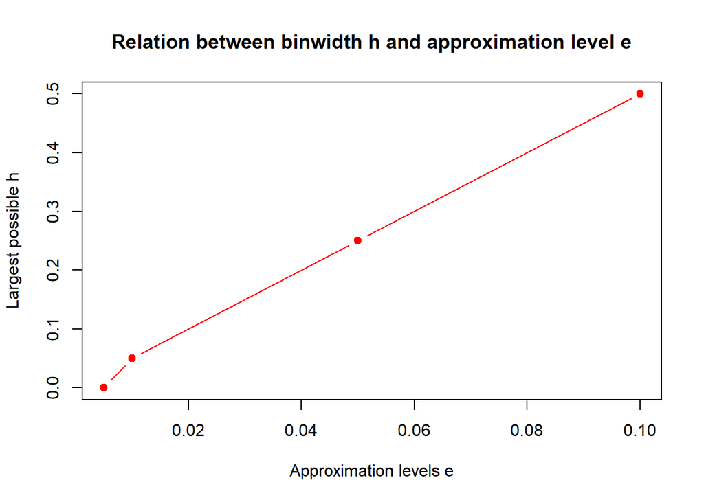

```r
# Plot the results to see how the largest h can variate with different epsilon
plot(table, type='b', pch=19, col='red',
     xlab = 'Approximation levels e', ylab = 'Largest possible h',
     main = 'Relation between binwidth h and approximation level e')
```

The plot shows us how the largest possible binwidth $h$ variates with $\epsilon$. We can say that the two are positively related.